# Aula20

Alex

2024-10-10

## Companhias aéreas

Vamos identificar quais são os atributos e as características que são relevantes e que podem gerar potencial de diferenciação para as companhias aéreas.

Desafio: traduzir este conjunto de números num mapa que nos permita analisar a posição relativa de cada uma dessas empresas.

```r
library(readxl)
dados = read_xlsx("companhias.xlsx")
dados = data.frame(dados, row.names = 1)
# Instalar o pacote factoextra
library(factoextra)
```

Vamos construir o mapa que mostra as características estatísticas da técnica.

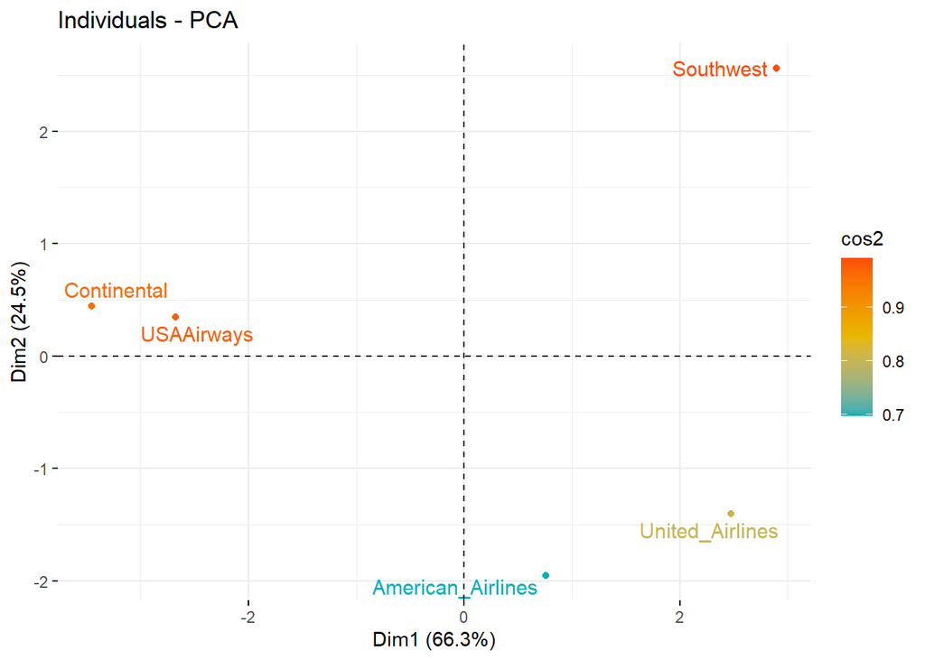

O percentual de explicação do mapa é a soma das porcentagens dos dois eixos: 66.3 + 24.5 = 91%

Quanto mais laranja, mais a companhia aérea está próxima do plano de duas dimensões. No caso, Southwest, Continental e USAAirways são as companhias que estão mais próximas da projeção no plano.

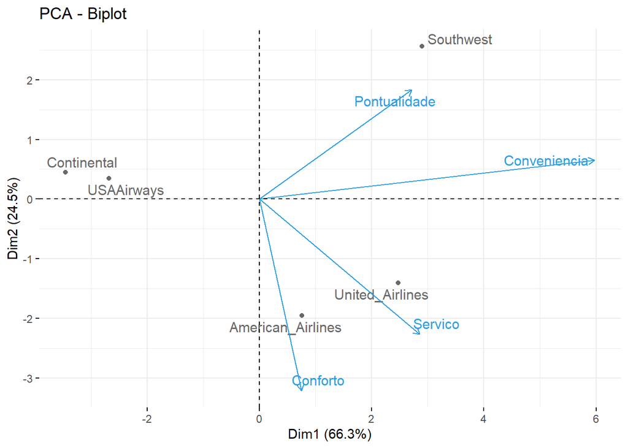

O Atributo mais importante na análise é a conveniência.Já a marca mais bem posicionada é a southwest, seguida de United, American etc.

Para pontualidade, os detaques seguem como na análise de conveniência. A marca mais bem posicionada é a Southwest, seguida da United, American etc.

Em relação ao serviço, destaca-se a companhia United. American ocupa a segunda posição.

Continental e USAAirways não são percebidas como destaque em nenhum dos atributos. A forma de continuarem competitivas é diminuido o preço da passagem.